# Final Project

### 46-923, Financial Data Science II

**Group**: PGHGroup19  
**Authors**: Soumil Banerjee(soumilb), Linghui Guan (linghuig), Yifeng Wang (yifengw5), Swarnava Sarkar (swarnavs)

# Hypothesis:

**Null**: Hidden Orders or Canceled order does not have a relationship with Predicted earnings surprise across different levels of Market Cap  
**Alternative**: Hidden Orders or Canceled order have a relationship with Predicted earnings surprise across different levels of Market Cap

```python
#Importing required libraries
import pandas as pd
import matplotlib.pyplot as plt
import numpy as np
from tqdm.notebook import trange
import os
import seaborn as sns
import warnings
warnings.filterwarnings('ignore')
import statsmodels.api as sm
from scipy.stats import norm
```

# 1. Pre-Processing

```python
cd /q/datastore/extractalpha_truebeats/protected/1.0/raw_data
```

```
/q/datastore/extractalpha_truebeats/protected/1.0/raw_data
```

```python
#Import data from the ExtractAlpha dataset
extractalpha = pd.read_csv('ExtractAlpha_FQ1_TrueBeats_SALES_History_US_NoCusip_2015_202312.csv.gz')
extractalpha['Date'] = pd.to_datetime(extractalpha['Date'])
```

```python
cd /q/datastore/sec_metrics_by_security/protected/1.0/raw_data
```

```
/q/datastore/sec_metrics_by_security/protected/1.0/raw_data
```

```python
# List of years to process for SEC data
years = list(range(2015, 2024))
dataframes = []

# Loop through each year's folder
for year in years:
    folder_path = os.path.join("", str(year))

    for file_name in os.listdir(folder_path):
        if file_name.endswith(".csv"):
            file_path = os.path.join(folder_path, file_name)
            try:

                df = pd.read_csv(file_path)

                # Optionally, add a column to track the year
                df['Year'] = year
                dataframes.append(df)
            except Exception as e:
                print(f"Error reading {file_path}: {e}")

# Concatenate all DataFrames into one
combined_df = pd.concat(dataframes, ignore_index=True)
combined_df['Date'] = pd.to_datetime(combined_df['Date'].astype(int).astype(str),
                                     format='%Y%m%d')
```

```python
## Join both dataframes and drop irrelevant columns
merged_data = pd.merge(combined_df, extractalpha, left_on=['Date', 'Ticker'], right_on=['Date', 'Ticker_PointInTime'], how='inner')
merged_data = merged_data.rename(columns={'Ticker_x':'Ticker'})
merged_data = merged_data.drop('Ticker_y', axis=1)

#Take only required columns
hidden_cols = [col for col in merged_data.columns if 'Hidden' in col]
req_cols = ['Date','Security','Ticker','McapRank','TrueBeat_SALES']
req_cols.extend(hidden_cols)
req_cols.append('Cancels')
req_data = merged_data[req_cols]
```

```python
# Drop NA and duplicates
clean_data = req_data.dropna().drop_duplicates(subset= ('Date','Security','Ticker'), keep='first')
```

```python
# Bucketing by MCAP.
# Create a new column for market cap categories, from above dist plot, we decide to assign
# 1) small to mkt cap rank 1-4
# 2) middle to mkt cap rank 5-7
# 3) large to mkt cap rank 8-10

bucket_data = clean_data.copy()
bucket_data['McapSize'] = bucket_data['McapRank'].apply(lambda x: 'Large' if x > 7 else ('Middle' if (x <= 7 and x > 4)  else 'Small'))
bucket_data['McapSize'] = bucket_data['McapSize'].astype('category').cat.as_unordered()
```

[output not shown]

# 2. Data Visualisation

### Histogram of Hidden orders, volume and Cancels

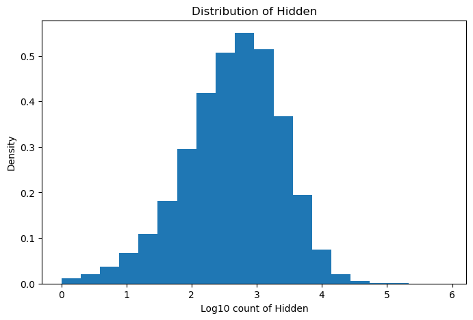

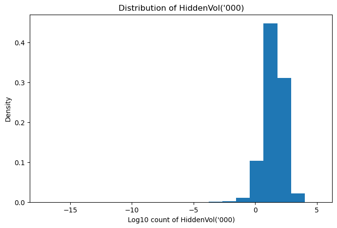

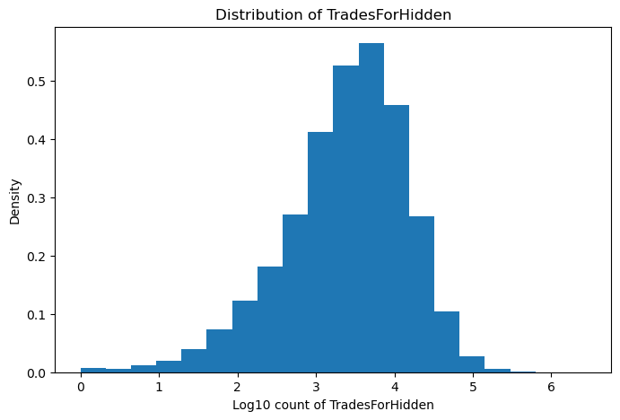

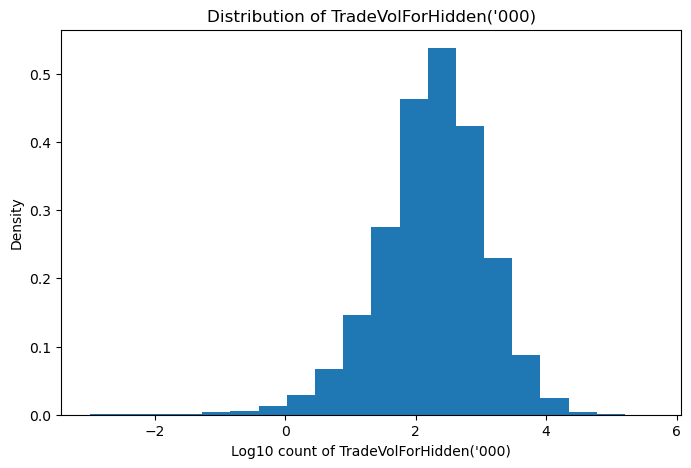

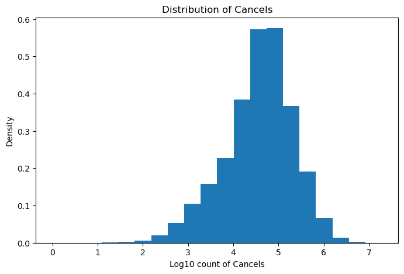

```python
columns = ['Hidden', 'HiddenVol(\'000)', 'TradesForHidden', 'TradeVolForHidden(\'000)', 'Cancels']

for col in columns:
    plt.figure(figsize=(8, 5))
    plt.hist(np.log10(req_data[col]\
                      [req_data[col] > 0]), bins=20, density=True)
    plt.title(f'Distribution of {col}')
    plt.xlabel(f"Log10 count of {col}")
    plt.ylabel('Density')
    plt.show()
```

### Bivariate relationship of Hidden and Cancel orders with TrueBeat_SALES

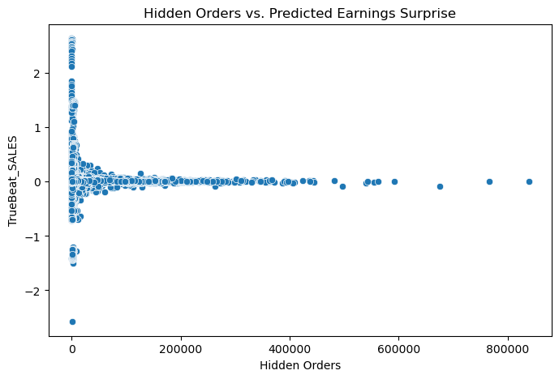

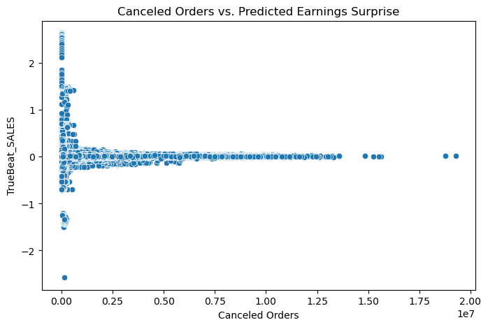

```python
# Hidden Orders vs. Earnings Surprise
plt.figure(figsize=(8, 5))
sns.scatterplot(data=bucket_data, x='Hidden', y='TrueBeat_SALES')
plt.title('Hidden Orders vs. Predicted Earnings Surprise')
plt.xlabel('Hidden Orders')
plt.ylabel('TrueBeat_SALES')
plt.show()

# Canceled Orders vs. Earnings Surprise
plt.figure(figsize=(8, 5))
sns.scatterplot(data=bucket_data, x='Cancels', y='TrueBeat_SALES')
plt.title('Canceled Orders vs. Predicted Earnings Surprise')
plt.xlabel('Canceled Orders')
plt.ylabel('TrueBeat_SALES')
plt.show()
```

There is no observable relationship between Hidden orders and predicted earnings surprise.

### Correlation Heatmap

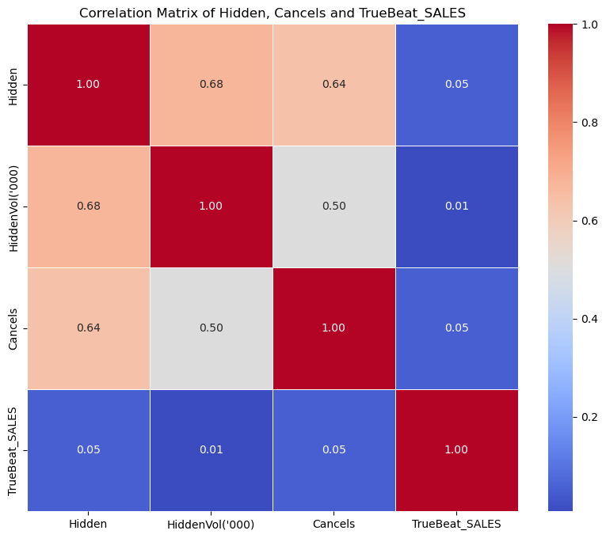

```python
numerical_cols = ['Hidden', 'HiddenVol(\'000)', 'Cancels', 'TrueBeat_SALES']
corr_matrix = req_data[numerical_cols].corr()

plt.figure(figsize=(10, 8))
sns.heatmap(corr_matrix, annot=True, cmap='coolwarm', fmt=".2f", linewidths=0.5)
plt.title('Correlation Matrix of Hidden, Cancels and TrueBeat_SALES')
plt.show()
```

We observe that our the earnings surprises for stocks have very low correlation with hidden and cancelled order data. This could imply that there is very low linear relationship between them. Linear metrics like correlation may not fully capture the dynamics. Further exploration with non-linear methods (e.g., kernel regression, KNN) is necessary to test the hypothesis.

We also observe that other hidden and cancelled order variables are moderately to highly correlated with each other.

### Correlation of TrueBeat_SALES with Cancels with McapSize

```python
correlation_results = pd.DataFrame()

for sec_type in bucket_data['Security'].unique():
    subset = bucket_data[bucket_data['Security'] == sec_type]

    for rank in subset['McapSize'].unique():
        rank_subset = subset[subset['McapSize'] == rank]

        corr = rank_subset[['TrueBeat_SALES', 'Cancels', 'Hidden']].corr()

        correlation_results = correlation_results.append({
            'Security': sec_type,
            'McapSize': rank,
            'TrueBeat_SALES_Cancels': corr.loc['TrueBeat_SALES', 'Cancels'],
            'TrueBeat_SALES_Hidden': corr.loc['TrueBeat_SALES', 'Hidden']
        }, ignore_index=True)
```

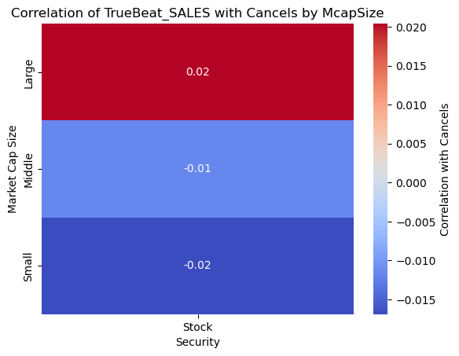

```python
heatmap_data = correlation_results.pivot(index='McapSize', columns='Security', values='TrueBeat_SALES_Cancels')

sns.heatmap(heatmap_data, annot=True, cmap='coolwarm', fmt=".2f", cbar_kws={'label': 'Correlation with Cancels'})
plt.title('Correlation of TrueBeat_SALES with Cancels by McapSize')
plt.ylabel('Market Cap Size')
plt.show()
```

The heatmap indicates weak correlations overall, with slightly negative values for lower to mid-market cap ranks and small positive values emerging for large-cap stocks. This pattern suggests that cancellation activity is only minimally related to earnings surprises for stocks, with a slight tendency for cancellations to align positively with higher earnings surprises in the large market cap stocks.

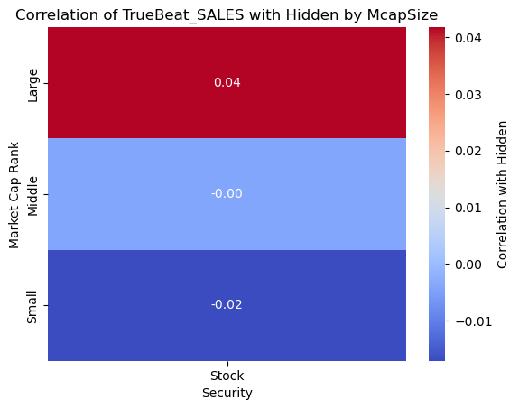

```python
heatmap_data2 = correlation_results.pivot(index='McapSize', columns='Security', values='TrueBeat_SALES_Hidden')

sns.heatmap(heatmap_data2, annot=True, cmap='coolwarm', fmt=".2f", cbar_kws={'label': 'Correlation with Hidden'})
plt.title('Correlation of TrueBeat_SALES with Hidden by McapSize')
plt.ylabel('Market Cap Rank')
plt.show()
```

The heatmap indicates that stocks with smaller market caps exhibit slightly negative correlations, suggesting that higher hidden order activity is weakly associated with lower earnings surprises for these groups. In contrast, stocks with higher market caps show small positive correlations.

### Cancels by MarketCapSize and Rank

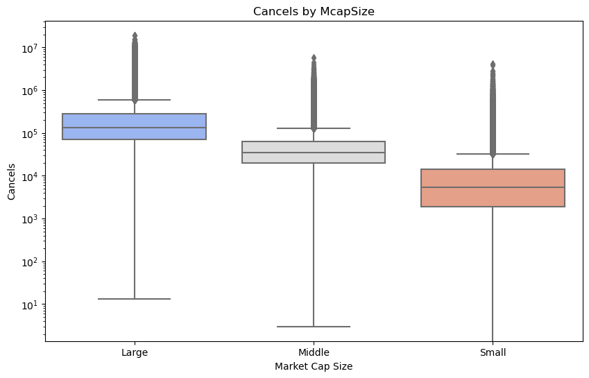

```python
plt.figure(figsize=(10, 6))
sns.boxplot(x='McapSize', y='Cancels', data=bucket_data, palette='coolwarm')
plt.title(f'Cancels by McapSize')
plt.xlabel('Market Cap Size')
plt.ylabel('Cancels')
plt.yscale('log')
plt.show()
```

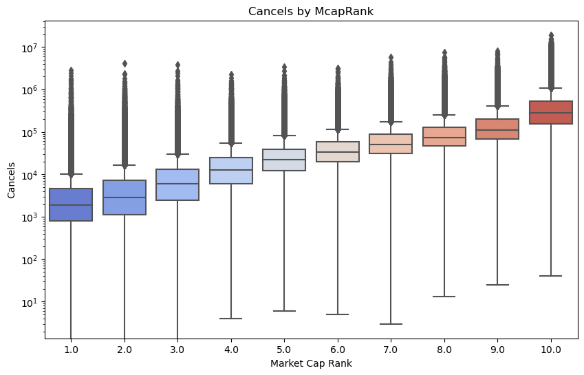

```python
plt.figure(figsize=(10, 6))
sns.boxplot(x='McapRank', y='Cancels', data=bucket_data, palette='coolwarm')
plt.title(f'Cancels by McapRank')
plt.xlabel('Market Cap Rank')
plt.ylabel('Cancels')
plt.yscale('log')
plt.show()
```

The boxplots support that cancellation activity may vary significantly by market cap, with larger-cap stocks exhibiting more frequent or volatile cancellation behavior.

### Hidden Orders and Volume over time

We create ratios by summing up all Hidden orders, Hidden volumes and Cancels over each day and visualise the trend

```python
grouped_hidden = bucket_data.groupby('Date')[['Hidden','TradesForHidden','HiddenVol(\'000)','TradeVolForHidden(\'000)','Cancels']].sum()
grouped_hidden['trade_ratio'] = grouped_hidden['Hidden'] / grouped_hidden['TradesForHidden']
grouped_hidden['vol_ratio'] = grouped_hidden['HiddenVol(\'000)'] / grouped_hidden['TradeVolForHidden(\'000)']
```

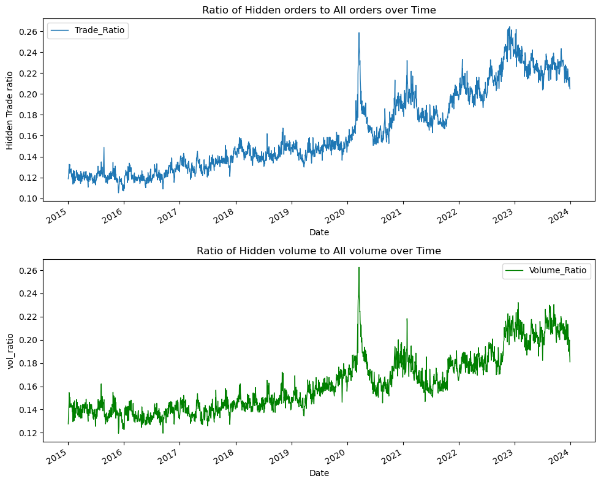

```python
fig, axes = plt.subplots(nrows=2, ncols=1, figsize=(10, 8))

grouped_hidden['trade_ratio'].plot(ax=axes[0], lw=1, label='Trade_Ratio')
axes[0].set_title('Ratio of Hidden orders to All orders over Time')
axes[0].set_xlabel("Date",size=10)
axes[0].set_ylabel("Hidden Trade ratio",size=10)
axes[0].legend()

grouped_hidden['vol_ratio'].plot(ax=axes[1], lw=1, color ='g', label='Volume_Ratio')
axes[1].set_title('Ratio of Hidden volume to All volume over Time')
axes[1].set_xlabel("Date",size=10)
axes[1].set_ylabel("vol_ratio",size=10)
axes[1].legend()

plt.tight_layout()
plt.show()
```

Over time, hidden orders and volume are increasing. There is a peak during COVID, suggesting that it could be due to companies trying to conceal their trades when they had to liquidate majority of their positions.

### Cancels over time

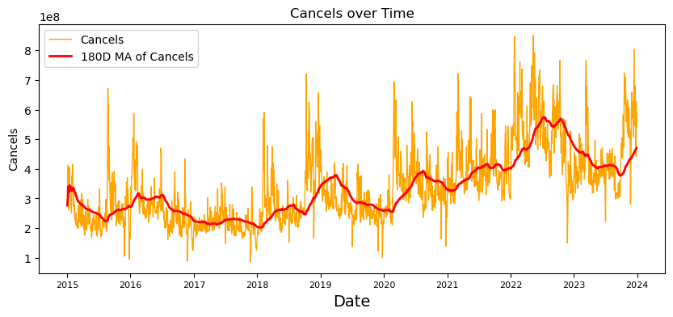

```python
## Calculate Moving average to see a trend
grouped_hidden['cancel_MA'] = grouped_hidden['Cancels'].rolling('180D').mean()
plt.figure(figsize=(10, 4))
plt.plot(grouped_hidden['Cancels'], lw=1, color='orange', label='Cancels')
plt.plot(grouped_hidden['cancel_MA'], lw=2, color='r', label='180D MA of Cancels')
plt.title('Cancels over Time')
plt.xlabel("Date",size=14)
plt.xticks(size=8)
plt.ylabel("Cancels",size=10)
plt.legend()
plt.show()
```

Number of orders canceled are also increasing over time. We can see this using the red line which shows a 6 month moving average. The cancels are increasing more gradually compared to Hidden orders and volume.

# 3. Data Analysis

## 3.1 Clustering

```python
#Import for clustering
from sklearn.cluster import KMeans
from scipy.cluster import hierarchy
```

### K-Means Clustering

We try 2 forms of K-Means clustering:

1. Using all numeric columns (except the rank columns)
2. Using only Hidden, HiddenVol and Cancels

We then analyse by comparing across McapSize.

```python
#Using all columns
clust_all = merged_data.dropna().drop_duplicates(subset= ('Date','Security','Ticker'), keep='first')
clust_all['McapSize'] = clust_all['McapRank'].apply(lambda x: 'Large' if x > 7 else ('Middle' if (x <= 7 and x > 4)  else 'Small'))
clust_all['McapSize'] = clust_all['McapSize'].astype('category').cat.as_unordered()

#Create new DF only for the numeric columns
cluster = clust_all.select_dtypes(include='float64')
non_rank_cols = [col for col in cluster.columns if 'Rank' not in col]
cluster = cluster[non_rank_cols]
```

```python
# Centre the data for KMeans
centred_data = cluster.copy()
centred_data[centred_data.columns] = (centred_data[centred_data.columns] - centred_data[centred_data.columns].mean()) / centred_data[centred_data.columns].std()
kminit = KMeans(n_clusters=5, n_init=10)
kmout = kminit.fit(centred_data)
```

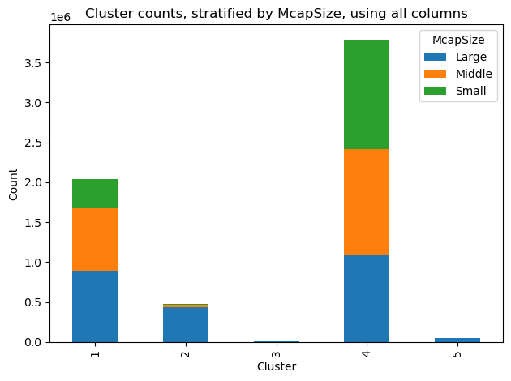

```python
#Plot the data to see if it is split across MCAP
clust_data = clust_all.copy()
clust_data['kmclust'] = kmout.labels_ + 1
clust_data["kmclust"] = clust_data["kmclust"].astype('category').cat.as_unordered()

df = clust_data.groupby(["kmclust", "McapSize"])["Ticker"].count().unstack("McapSize").fillna(0)
df.plot(kind='bar', stacked=True, legend=False)
plt.xlabel("Cluster")
plt.ylabel("Count")
plt.legend(title="McapSize", bbox_to_anchor=(1.0, 1.0))
plt.title('Cluster counts, stratified by McapSize, using all columns', fontsize =12)
plt.tight_layout()
plt.show()
```

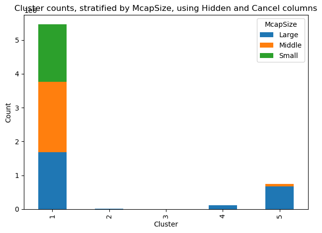

```python
#Using only 3 columns
cluster_data = bucket_data[['Hidden','HiddenVol(\'000)','Cancels']]
centred_data = cluster_data.copy()
centred_data[centred_data.columns] = (centred_data[centred_data.columns] - centred_data[centred_data.columns].mean()) / centred_data[centred_data.columns].std()
kminit = KMeans(n_clusters=5, n_init=10)
kmout = kminit.fit(centred_data)

clust_data = bucket_data.copy()
clust_data['kmclust'] = kmout.labels_ + 1
clust_data["kmclust"] = clust_data["kmclust"].astype('category').cat.as_unordered()

df = clust_data.groupby(["kmclust", "McapSize"])["Ticker"].count().unstack("McapSize").fillna(0)
df.plot(kind='bar', stacked=True, legend=False)
plt.xlabel("Cluster")
plt.ylabel("Count")
plt.legend(title="McapSize", bbox_to_anchor=(1.0, 1.0))
plt.title('Cluster counts, stratified by McapSize, using Hidden and Cancel columns', fontsize =12)
plt.tight_layout()
plt.show()
```

We see that clustering in both cases does not really give us definite differences accross market cap sizes.

When using all columns, Cluster 1 is dominated by middle and large cap stocks while cluster 4 has a more even split. Cluster 3 and 5 barely have any stocks. Cluster 2 seems to be dominated by large cap stocks.

When using only the required 3 columns, (`Hidden`,`HiddenVol(\'000)`,`Cancels`), Cluster 5 is dominated by large cap stocks while Cluster 1 has an even split. The other clusters barely have any stocks in them.

We can also try clustering by summing the data across all dates and see if McapSize is a differentiating factor for hidden and canceled orders.

```python
sum_data = bucket_data[['McapSize','Ticker','Hidden','HiddenVol(\'000)','Cancels']]
summed_cluster_data = sum_data.groupby(['McapSize','Ticker']).sum()
summed_cluster_data = summed_cluster_data.reset_index()

#Numeric columns only for clustering
req_cluster_data = summed_cluster_data[['Hidden','HiddenVol(\'000)','Cancels']]
centred_data = req_cluster_data.copy()
centred_data[centred_data.columns] = (centred_data[centred_data.columns] - centred_data[centred_data.columns].mean()) / centred_data[centred_data.columns].std()
```

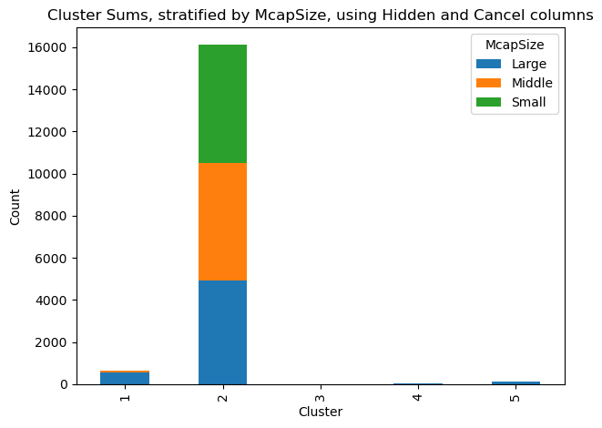

```python
kminit = KMeans(n_clusters=5, n_init=10)
kmout = kminit.fit(centred_data)

clust_data = summed_cluster_data.copy()
clust_data['kmclust'] = kmout.labels_ + 1
clust_data["kmclust"] = clust_data["kmclust"].astype('category').cat.as_unordered()

df = clust_data.groupby(["kmclust", "McapSize"])["Ticker"].count().unstack("McapSize").fillna(0)
df.plot(kind='bar', stacked=True, legend=False)
plt.xlabel("Cluster")
plt.ylabel("Count")
plt.legend(title="McapSize", bbox_to_anchor=(1.0, 1.0))
plt.title('Cluster Sums, stratified by McapSize, using Hidden and Cancel columns', fontsize =12)
plt.tight_layout()
plt.show()
```

We see that summing the data has a negative effect on the stratification as now all stocks are bunched up into one cluster due to the presence of outliers. The summing up highlights the outliers even more making them to be a separate group while the rest are lumped into one big group in Cluster 2.

### Hierarchical Clustering

We must use the summed data as the data size is too large and we are unable to perform hierarchical clustering over millions of records.

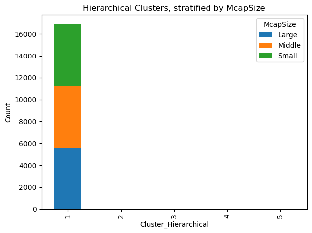

```python
hcout = hierarchy.linkage(centred_data, method="complete")
labels = hierarchy.fcluster(hcout, t=5, criterion = "maxclust")
clust_data = summed_cluster_data.copy()
clust_data["hclust"] = labels
clust_data["hclust"] = clust_data["hclust"].astype('category').cat.as_unordered()

df = clust_data.groupby(["hclust", "McapSize"])["Ticker"].count().unstack("McapSize").fillna(0)
df.plot(kind='bar', stacked=True, legend=False)
plt.xlabel("Cluster_Hierarchical")
plt.ylabel("Count")
plt.legend(title="McapSize", bbox_to_anchor=(1.0, 1.0))
plt.title('Hierarchical Clusters, stratified by McapSize', fontsize =12)
plt.tight_layout()
plt.show()
```

As we see, hierarchical clustering performs even worse as all the stocks are bunched up into Cluster 1 with very few stocks in the other clusters. But this actually leads to a more interesting observation.

Let's look at the groups with the smallest number of stocks.

```python
small_clusters = clust_data[clust_data['hclust'].isin([3,4,5])]
this_list = small_clusters['Ticker'].unique().tolist()
list_data = bucket_data[bucket_data['Ticker'].isin(this_list)]
list_data.groupby('Ticker')['McapRank'].unique()
```

```
Ticker
AAPL                   [10.0]
AMD     [8.0, 7.0, 9.0, 10.0]
BAC                    [10.0]
F                      [10.0]
GE                     [10.0]
MSFT                   [10.0]
NVDA                   [10.0]
SIRI                   [10.0]
T                      [10.0]
TSLA                   [10.0]
Name: McapRank, dtype: object
```

We see that these stock Tickers are familiar. They are all extremely large cap stocks (except AMD which has come up the ranks). Although they fall in the high McapSize, they can be considered to be well higher in MarketCap than the other tickers in that group.

## 3.2 Dimension Reduction (PCA)

```python
pca_features = ["Hidden", "HiddenVol('000)", "TradesForHidden", "TradeVolForHidden('000)", "Cancels"]
pca_data = bucket_data.copy()
pca_data[pca_features] = pca_data[pca_features].replace([np.inf, -np.inf], np.nan)
pca_data = pca_data.dropna(subset=pca_features)
```

```python
from sklearn.preprocessing import StandardScaler
from sklearn.decomposition import PCA

scaler = StandardScaler()
standardized_features = scaler.fit_transform(pca_data[pca_features])

pca = PCA()
pca.fit(standardized_features)
print(np.round(pca.explained_variance_ratio_, 3))
print(np.cumsum(pca.explained_variance_ratio_))
```

```
[0.774 0.129 0.077 0.014 0.006]
[0.77432947 0.90358205 0.98025051 0.99427484 1.        ]
```

We see that first 2 components explain about 90% of the variation.

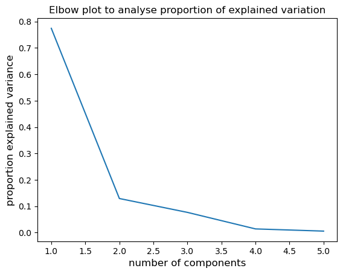

```python
plt.plot(range(1,6), pca.explained_variance_ratio_)
plt.xlabel('number of components', size=12)
plt.ylabel('proportion explained variance', size=12)
plt.title('Elbow plot to analyse proportion of explained variation')
plt.show()
```

```python
print(pca.components_)
```

```
[[ 0.43638771  0.4407879   0.48870325  0.45075101  0.41625047]
 [-0.24098644  0.57892615 -0.26825752  0.47304279 -0.55770824]
 [ 0.75768482  0.08367022  0.0314217  -0.34394134 -0.54738472]
 [ 0.02431417  0.60543866 -0.45907735 -0.5004554   0.41430089]
 [-0.42049237  0.31143839  0.69099037 -0.45199866 -0.21076483]]
```

For the first principal component, all features contribute almost equally. It is likely that this component represents as general measure of activity.

For the second component, HiddenVol and Cancels have the strongest but opposite contributions, suggesting that the second principal component reflects a trade-off between these 2 features. It suggests that PC2 may be distinguishing between scenarios dominated by high hidden trade volumes and those dominated by frequent cancellations. This contrast indicates the different trading behaviors that PC2 captures: strategic large trades versus more reactive, frequent actions like cancellations.

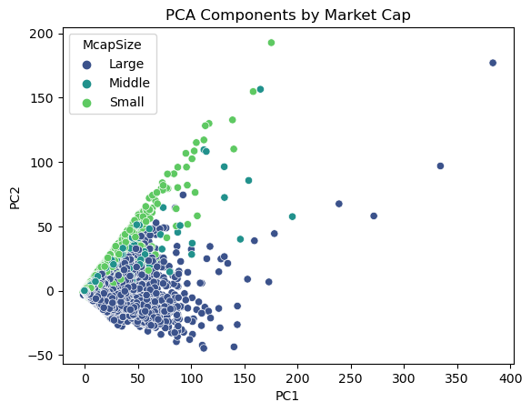

```python
pca = PCA(n_components=2)
reduced_data = pca.fit_transform(standardized_features)
pca_data['PC1'] = reduced_data[:, 0]
pca_data['PC2'] = reduced_data[:, 1]

sns.scatterplot(data=pca_data, x='PC1', y='PC2', hue='McapSize', palette='viridis')
plt.title('PCA Components by Market Cap')
plt.show()
```

According to the plot, smaller-cap stocks cluster near the origin, indicating consistent and less variable trading behaviors, while larger-cap stocks show greater dispersion along PC1. This suggests that larger-cap stocks exhibit more diverse trading patterns, such as frequent hidden orders or cancellations, which may have a stronger impact on earnings surprises compared to smaller-cap stocks.

```python
correlations = pca_data[['PC1', 'PC2', 'TrueBeat_SALES']].corr()
print(correlations)
```

```
                         PC1           PC2  TrueBeat_SALES
PC1             1.000000e+00  8.984374e-15        0.034248
PC2             8.984374e-15  1.000000e+00       -0.061220
TrueBeat_SALES  3.424843e-02 -6.121967e-02        1.000000
```

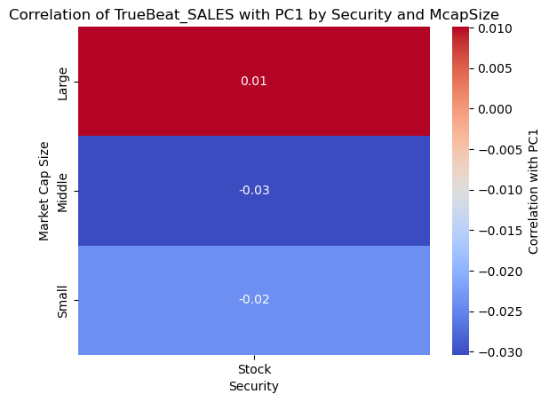

```python
correlation_results = pd.DataFrame()

for rank in pca_data['McapSize'].unique():
    rank_subset = pca_data[pca_data['McapSize'] == rank]
    corr = rank_subset[['TrueBeat_SALES', 'PC1', 'PC2']].corr()

    correlation_results = correlation_results.append({
        'Security': 'Stock',
        'McapSize': rank,
        'TrueBeat_SALES_PC1': corr.loc['TrueBeat_SALES', 'PC1'],
        'TrueBeat_SALES_PC2': corr.loc['TrueBeat_SALES', 'PC2']
    }, ignore_index=True)

heatmap_data = correlation_results.pivot(index='McapSize', columns='Security', values='TrueBeat_SALES_PC1')

sns.heatmap(heatmap_data, annot=True, cmap='coolwarm', fmt=".2f", cbar_kws={'label': 'Correlation with PC1'})
plt.title('Correlation of TrueBeat_SALES with PC1 by Security and McapSize')
plt.ylabel('Market Cap Size')
plt.show()
```

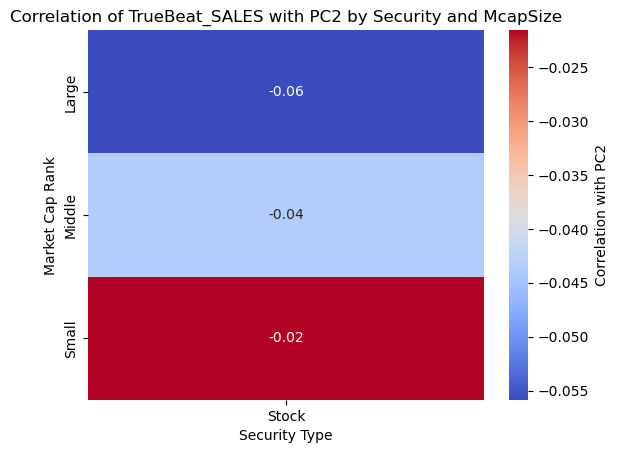

```python
heatmap_data_pc2 = correlation_results.pivot(index='McapSize', columns='Security', values='TrueBeat_SALES_PC2')

sns.heatmap(heatmap_data_pc2, annot=True, cmap='coolwarm', fmt=".2f", cbar_kws={'label': 'Correlation with PC2'})
plt.title('Correlation of TrueBeat_SALES with PC2 by Security and McapSize')
plt.ylabel('Market Cap Rank')
plt.xlabel('Security Type')
plt.show()
```

For PC1, the correlations are weak across all market cap ranks, with a slight positive trend appearing for larger-cap stocks.  
For PC2, the correlations remain consistently negative, with slightly stronger negative correlations for large-cap stocks. These findings suggest that neither PC1 nor PC2 shows a strong or clear relationship with earnings surprises. This could further be confirmed through hypothesis testing following section.

## 3.3 Kernel Density Estimation

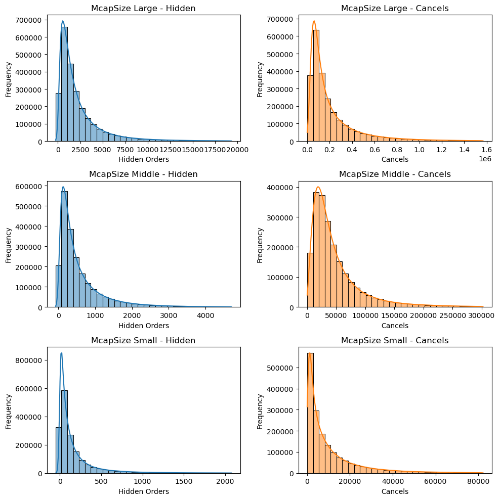

```python
col_plot = ['Hidden', 'Cancels']
fig, axs = plt.subplots(3, 2, figsize=(10, 10))

# Loop through each market cap to plot the distribution of Hidden and Cancels with kde
# remove outliers

for i, cap_r in enumerate(['Large','Middle','Small']):
    df = bucket_data[bucket_data['McapSize'] == cap_r]

    df = df[df['Hidden'] < df['Hidden'].quantile(0.99)]
    df = df[df['Cancels'] < df['Cancels'].quantile(0.99)]

    # Plot Hidden
    sns.histplot(df['Hidden'], ax=axs[i, 0], kde=True, color='tab:blue', bins=30)
    axs[i, 0].set_title(f'McapSize {cap_r} - Hidden')
    axs[i, 0].set_ylabel('Frequency')
    axs[i, 0].set_xlabel('Hidden Orders')

    # Plot Cancels
    sns.histplot(df['Cancels'], ax=axs[i, 1], kde=True, color='tab:orange', bins=30)
    axs[i, 1].set_title(f'McapSize {cap_r} - Cancels')
    axs[i, 1].set_ylabel('Frequency')
    axs[i, 1].set_xlabel('Cancels')

plt.tight_layout()
plt.show()
```

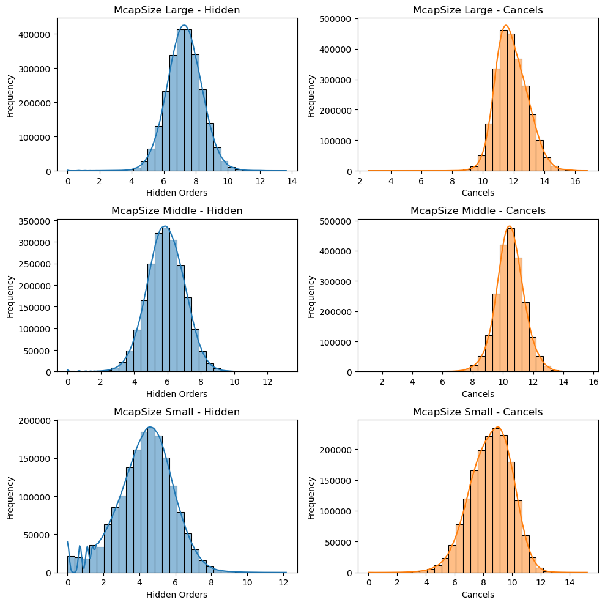

```python
col_plot = ['Hidden', 'Cancels']
fig, axs = plt.subplots(3, 2, figsize=(10, 10))

# Loop through each market cap to plot the distribution of Hidden and Cancels with kde
# remove outliers

for i, cap_r in enumerate(['Large','Middle','Small']):
    df = bucket_data[bucket_data['McapSize'] == cap_r]

    # Plot Hidden
    sns.histplot(np.log(df['Hidden']), ax=axs[i, 0], kde=True, color='tab:blue', bins=30)
    axs[i, 0].set_title(f'McapSize {cap_r} - Hidden')
    axs[i, 0].set_ylabel('Frequency')
    axs[i, 0].set_xlabel('Hidden Orders')

    # Plot Cancels
    sns.histplot(np.log(df['Cancels']), ax=axs[i, 1], kde=True, color='tab:orange', bins=30)
    axs[i, 1].set_title(f'McapSize {cap_r} - Cancels')
    axs[i, 1].set_ylabel('Frequency')
    axs[i, 1].set_xlabel('Cancels')

plt.tight_layout()
plt.show()
```

Across all market cap sizes, Hidden and Cancels seem to be log-normally distributed.

```python
def plot_quantile_analysis(stock, rank, col, target_col='TrueBeat_SALES', quantiles=[0, 0.25, 0.5, 0.75, 1.0]):
    """
    Plot KDE for truebeats conditioned on quantiles (divide into 4 quantiles) of another column for a specific McapSize
    """

    quantile_labels = [f'Q{i+1}' for i in range(len(quantiles) - 1)]
    df = stock[stock['McapSize'] == rank]
    df[f'{col}_QuantileGroup'] = pd.qcut(df[col], q=quantiles, labels=quantile_labels, duplicates='drop')

    fig, axs = plt.subplots(1, len(quantile_labels), figsize=(5 * len(quantile_labels), 6), sharey=True)
    fig.suptitle(f'{target_col} KDE for {col} Quantiles (McapSize = {rank})', fontsize=16)

    for ax, quantile in zip(axs, quantile_labels):
        subset = df[df[f'{col}_QuantileGroup'] == quantile]

        # Fit KDE for the target column
        kde = sm.nonparametric.KDEUnivariate(subset[target_col])
        kde.fit()

        ax.hist(subset[target_col], bins=30, density=True, alpha=0.5, label='Histogram', color='gray')
        ax.plot(kde.support, kde.density, label='Density', color='blue')
        # CDF is very very slow to excute ... unable to output actually
        # ax.plot(kde.support, kde.cdf, label='CDF'linestyle='--')

        ax.set_title(f'{quantile} Quantile')
        ax.set_xlabel(target_col)
        ax.set_ylabel('Density')
        ax.legend()

    plt.tight_layout()
    plt.show()
```

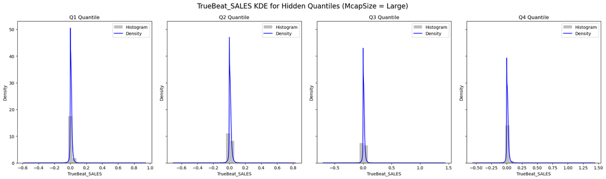

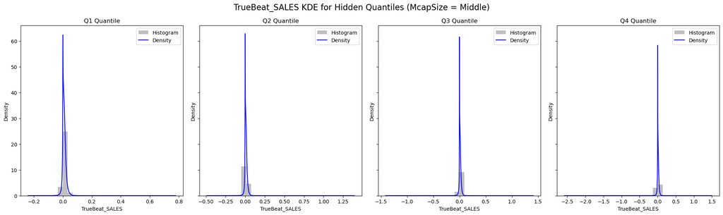

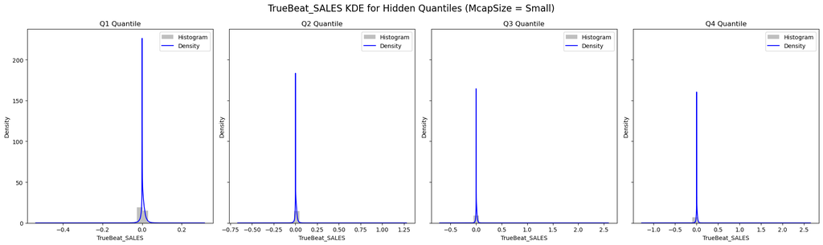

```python
for cap_r in ['Large','Middle','Small']:
    plot_quantile_analysis(
        stock=bucket_data,
        rank=cap_r,
        col='Hidden',
        target_col='TrueBeat_SALES'
    )
```

1. Across all market cap sizes and hidden quantiles, the KDE plots for TrueBeat_SALES are heavily centered around 0
2. No very obvious pattern across different market cap sizes
3. Given same market cap sizes, higher Hidden generally correspond to larger variance in TrueBeat Sales (observing the range of values), especially large variablity in middle size firms with high Hidden.

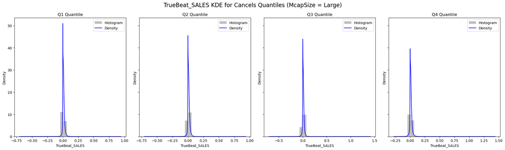

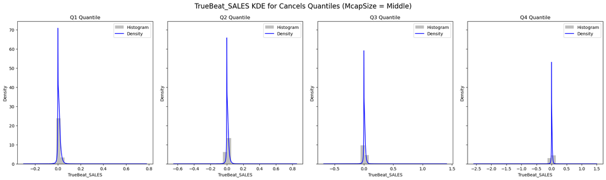

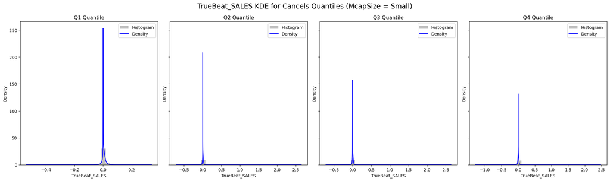

```python
for cap_r in ['Large','Middle','Small']:
    plot_quantile_analysis(
        stock=bucket_data,
        rank=cap_r,
        col='Cancels',
        target_col='TrueBeat_SALES'
    )
```

1. Across all Market cap Size and cancels quantiles, the KDE plots for TrueBeat_SALES are heavily centered around 0.
2. Large variablity in Middle size firms with Higher Cancels (Quantile 4)

## 3.4 Non-parametric Regresssion

```python
from sklearn.preprocessing import StandardScaler

features = ['Hidden', 'HiddenVol(\'000)', 'TradesForHidden', 'TradeVolForHidden(\'000)', 'Cancels']
target = 'TrueBeat_SALES'

# Drop rows with missing values in only the relevant columns
data = bucket_data.dropna(subset=features + [target])

# Aggregate data
agg_data = data.groupby("Ticker")[features+[target]].mean().reset_index()
```

```python
# Split aggregated data into X (predictors) and y (response)
X = agg_data[features].values
y = agg_data[target].values

# Standardize data
scaler = StandardScaler()
X_scaled = scaler.fit_transform(X)
```

### Kernel Regression

```python
from statsmodels.nonparametric.kernel_regression import KernelReg

from sklearn.kernel_ridge import KernelRidge
from sklearn.metrics import mean_squared_error, r2_score

kr_model = KernelReg(endog=y, exog=X_scaled, var_type='ccccc', reg_type='ll')

y_pred, _ = kr_model.fit(X_scaled)
```

[output not shown]

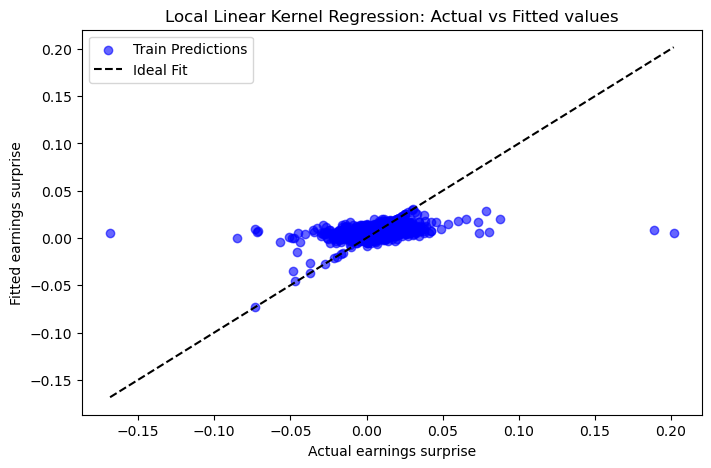

```python
r2 = r2_score(y, y_pred)
rmse = np.sqrt(mean_squared_error(y, y_pred))

print("Local Linear Kernel Regression Results:")
print(f"R^2 score: {r2}")
print(f"RMSE: {rmse}")

# Scatter plot for local linear regression
plt.figure(figsize=(8, 5))
plt.scatter(y, y_pred, alpha=0.6, label='Train Predictions', color='blue')
plt.plot([y.min(), y.max()], [y.min(), y.max()], '--', color='black', label='Ideal Fit')
plt.title('Local Linear Kernel Regression: Actual vs Fitted values')
plt.xlabel('Actual earnings surprise')
plt.ylabel('Fitted earnings surprise')
plt.legend()
plt.show()
```

We have a moderately low value of $R^2$. Most of our data is concentrated around 0.  
We see a random scatter around 0 as well. Thus, we see that we don't see any good fit from our Kernel Regression.

### KNN Regression

```python
from sklearn.neighbors import KNeighborsRegressor
from sklearn.model_selection import cross_val_score, KFold
from sklearn.metrics import mean_squared_error, make_scorer

mse_scorer = make_scorer(mean_squared_error, greater_is_better=False)
kfold = KFold(n_splits=5, shuffle=True, random_state=42)

best_rmse = float('inf')
rmse_scores = []
best_k = None

for neighbors in range(5, 51):
    knn_model = KNeighborsRegressor(n_neighbors=neighbors)
    cv_rmse = np.sqrt(-np.mean(cross_val_score(knn_model, X_scaled, y, cv=kfold, scoring=mse_scorer)))
    rmse_scores.append(cv_rmse)
    if cv_rmse < best_rmse:
        best_rmse = cv_rmse
        best_k = neighbors
```

[output not shown]

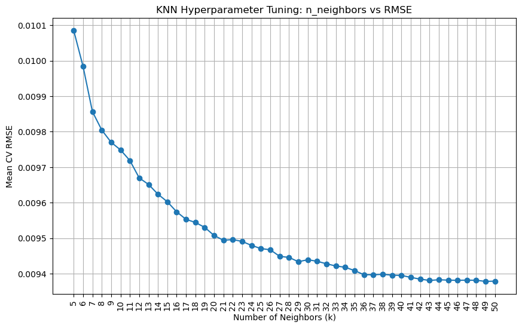

```python
print(f"Best k: {best_k} with Mean CV RMSE: {best_rmse}")

# Plot RMSE vs n_neighbors
plt.figure(figsize=(10, 6))
plt.plot(range(5, 51), rmse_scores, marker='o')
plt.title('KNN Hyperparameter Tuning: n_neighbors vs RMSE')
plt.xlabel('Number of Neighbors (k)')
plt.ylabel('Mean CV RMSE')
plt.xticks(range(5, 51), rotation=90)
plt.grid()
plt.show()
```

```python
knn_model = KNeighborsRegressor(n_neighbors=47).fit(X_scaled, y)

y_pred = knn_model.predict(X_scaled)

print("KNN Regression Results:")
print(f"R^2 score: {r2_score(y, y_pred)}")
print(f"RMSE: {np.sqrt(mean_squared_error(y, y_pred))}")
```

```
KNN Regression Results:
R^2 score: 0.1936726756206728
RMSE: 0.009182496483333774
```

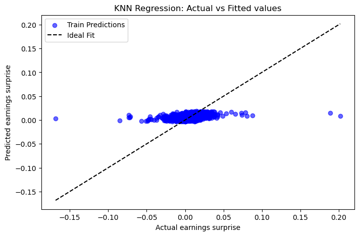

```python
# Scatter plot for KNN Regression
plt.figure(figsize=(8, 5))
plt.scatter(y, y_pred, alpha=0.6, label='Train Predictions', color='blue')
plt.plot([y.min(), y.max()], [y.min(), y.max()], '--', color='black', label='Ideal Fit')
plt.title('KNN Regression: Actual vs Fitted values')
plt.xlabel('Actual earnings surprise')
plt.ylabel('Predicted earnings surprise')
plt.legend()
plt.show()
```

We have a moderately low value of $R^2$. However, we see that most of our data is concentrated around 0.  
Around 0, we see we get random scatter as well. Thus, we see that we don't see any good fit from our KNN regression as well.

## 3.5 Hypothesis Testing

#### 1. **Null Hypothesis:** There is no linear relationship between Cancels, Hidden and TrueBeat_SALES across McapSizes

```python
df = bucket_data.copy()

response = 'TrueBeat_SALES'
predictors = ['Hidden', "HiddenVol('000)", 'Cancels']
dummies = pd.get_dummies(df['McapSize'], prefix='McapSize', drop_first=True)

X = pd.concat([df[predictors], dummies], axis=1)
X = sm.add_constant(X)
y = df[response]

# Fit regression
model = sm.OLS(y, X)
results = model.fit()
results.summary()
```

OLS Regression Results

| Dep. Variable: | TrueBeat_SALES | R-squared: | 0.023 |
| --- | --- | --- | --- |
| Model: | OLS | Adj. R-squared: | 0.023 |
| Method: | Least Squares | F-statistic: | 2.966e+04 |
| Date: | Fri, 06 Dec 2024 | Prob (F-statistic): | 0.00 |
| Time: | 14:07:09 | Log-Likelihood: | 1.5451e+07 |
| No. Observations: | 6350458 | AIC: | -3.090e+07 |
| Df Residuals: | 6350452 | BIC: | -3.090e+07 |
| Df Model: | 5 |  |  |
| Covariance Type: | nonrobust |  |  |

|  | coef | std err | t | P>\|t\| | [0.025 | 0.975] |
| --- | --- | --- | --- | --- | --- | --- |
| const | 0.0115 | 1.59e-05 | 725.135 | 0.000 | 0.011 | 0.012 |
| Hidden | 3.072e-07 | 3.4e-09 | 90.419 | 0.000 | 3.01e-07 | 3.14e-07 |
| HiddenVol('000) | -2.56e-06 | 2.67e-08 | -95.894 | 0.000 | -2.61e-06 | -2.51e-06 |
| Cancels | 1.664e-10 | 4.01e-11 | 4.150 | 0.000 | 8.78e-11 | 2.45e-10 |
| McapSize_Middle | -0.0014 | 2.08e-05 | -69.355 | 0.000 | -0.001 | -0.001 |
| McapSize_Small | -0.0073 | 2.25e-05 | -322.823 | 0.000 | -0.007 | -0.007 |

| Omnibus: | 9386718.430 | Durbin-Watson: | 1.858 |
| --- | --- | --- | --- |
| Prob(Omnibus): | 0.000 | Jarque-Bera (JB): | 342031177496.119 |
| Skew: | 7.515 | Prob(JB): | 0.00 |
| Kurtosis: | 1139.836 | Cond. No. | 1.09e+06 |

Notes:  
[1] Standard Errors assume that the covariance matrix of the errors is correctly specified.  
[2] The condition number is large, 1.09e+06. This might indicate that there are  
strong multicollinearity or other numerical problems.

#### 2. **Null Hypothesis:** There is no linear relationship between PC1 or PC2 and TrueBeat_SALES

```python
clean_data = pca_data[['PC1', 'PC2', 'TrueBeat_SALES']].replace([np.inf, -np.inf], np.nan).dropna()

X = clean_data[['PC1', 'PC2']]
y = clean_data['TrueBeat_SALES']
X = sm.add_constant(X)

model = sm.OLS(y, X).fit()
model.summary()
```

OLS Regression Results

| Dep. Variable: | TrueBeat_SALES | R-squared: | 0.005 |
| --- | --- | --- | --- |
| Model: | OLS | Adj. R-squared: | 0.005 |
| Method: | Least Squares | F-statistic: | 1.570e+04 |
| Date: | Fri, 06 Dec 2024 | Prob (F-statistic): | 0.00 |
| Time: | 14:07:11 | Log-Likelihood: | 1.5393e+07 |
| No. Observations: | 6350458 | AIC: | -3.079e+07 |
| Df Residuals: | 6350455 | BIC: | -3.079e+07 |
| Df Model: | 2 |  |  |
| Covariance Type: | nonrobust |  |  |

|  | coef | std err | t | P>\|t\| | [0.025 | 0.975] |
| --- | --- | --- | --- | --- | --- | --- |
| const | 0.0092 | 8.5e-06 | 1076.896 | 0.000 | 0.009 | 0.009 |
| PC1 | 0.0004 | 4.32e-06 | 86.520 | 0.000 | 0.000 | 0.000 |
| PC2 | -0.0016 | 1.06e-05 | -154.655 | 0.000 | -0.002 | -0.002 |

| Omnibus: | 9239960.169 | Durbin-Watson: | 1.857 |
| --- | --- | --- | --- |
| Prob(Omnibus): | 0.000 | Jarque-Bera (JB): | 316298076464.636 |
| Skew: | 7.267 | Prob(JB): | 0.00 |
| Kurtosis: | 1096.234 | Cond. No. | 2.45 |

Notes:  
[1] Standard Errors assume that the covariance matrix of the errors is correctly specified.

The p value of the coefficients of both PC1 and PC2 are significant, which allows us to reject the null hypothesis and conclude that both PC1 and PC2 have linear relationships with TrueBeat_SALES. However, the low $R^2$ indicates that PC1 and PC2 alone do not explain much of the variation in TrueBeat_SALES.

# 4. Conclusion